# Part I - Loan Data from Prosper

## Introduction

This dataset contains the data for more than 110 thousands loans with various informations about each loan.

## Preliminary Wrangling

The dataset has 81 different information about each loan (more detailed column description can be found [here](https://docs.google.com/spreadsheets/d/1gDyi_L4UvIrLTEC6Wri5nbaMmkGmLQBk-Yx3z0XDEtI/edit#gid=0). However not all of them are important in case of this analysis and visualizations, so 22 the most important features about each loan was chosen. That columns are (together with their description):

1. `ListingKey`: Unique key for each listing, same value as the 'key' used in the listing object in the API.
2. `DateCreditPulled`: The date the credit profile was pulled.
3. `Term`: The length of the loan expressed in months.
4. `LoanStatus`: The current status of the loan: Cancelled, Chargedoff, Completed, Current, Defaulted, FinalPaymentInProgress, PastDue. The PastDue status will be accompanied by a delinquency bucket.
5. `Investors`: The number of investors that funded the loan.
6. `BorrowerAPR`: The Borrower's Annual Percentage Rate (APR) for the loan.
7. `BorrowerRate`: The Borrower's interest rate for this loan.
8. `ListingCategory`: The category of the listing that the borrower selected when posting their listing: 0 - Not Available, 1 - Debt Consolidation, 2 - Home Improvement, 3 - Business, 4 - Personal Loan, 5 - Student Use, 6 - Auto, 7- Other, 8 - Baby&Adoption, 9 - Boat, 10 - Cosmetic Procedure, 11 - Engagement Ring, 12 - Green Loans, 13 - Household Expenses, 14 - Large Purchases, 15 - Medical/Dental, 16 - Motorcycle, 17 - RV, 18 - Taxes, 19 - Vacation, 20 - Wedding Loans
9. `BorrowerState`: The two letter abbreviation of the state of the address of the borrower at the time the Listing was created.
10. `Occupation`: The Occupation selected by the Borrower at the time they created the listing.
11. `EmploymentStatus`: The employment status of the borrower at the time they posted the listing.
12. `EmploymentStatusDuration`: The length in months of the employment status at the time the listing was created.
13. `IsBorrowerHomeowner`: A Borrower will be classified as a homowner if they have a mortgage on their credit profile or provide documentation confirming they are a homeowner.
14. `TotalCreditLinespast7years`: Number of credit lines in the past seven years at the time the credit profile was pulled.
15. `PercentFunded`: Percent the listing was funded.
16. `MonthlyLoanPayment`: The scheduled monthly loan payment.
17. `LoanOriginalAmount`: The origination amount of the loan.
18. `LoanMonthsSinceOrigination`: Number of months since the loan originated.
19. `StatedMonthlyIncome`: The monthly income the borrower stated at the time the listing was created.
20. `IncomeRange`: The income range of the borrower at the time the listing was created.
21. `CreditScoreRangeLower`: The lower value representing the range of the borrower's credit score as provided by a consumer credit rating agency.
22. `CreditScoreRangeUpper`: The upper value representing the range of the borrower's credit score as provided by a consumer credit rating agency.

```python
# import all packages and set plots to be embedded inline
import numpy as np
import pandas as pd
import matplotlib.pyplot as plt
import seaborn as sb
import warnings

%matplotlib inline
pd.set_option('display.max_columns', None) # display all the columns when printing the dataframe
warnings.filterwarnings('ignore')
```

```python
# Load the dataset
df = pd.read_csv('./prosperLoanData.csv')
df.head()
```

|  | ListingKey | ListingNumber | ListingCreationDate | CreditGrade | Term | LoanStatus | ClosedDate | BorrowerAPR | BorrowerRate | LenderYield | EstimatedEffectiveYield | EstimatedLoss | EstimatedReturn | ProsperRating (numeric) | ProsperRating (Alpha) | ProsperScore | ListingCategory (numeric) | BorrowerState | Occupation | EmploymentStatus | EmploymentStatusDuration | IsBorrowerHomeowner | CurrentlyInGroup | GroupKey | DateCreditPulled | CreditScoreRangeLower | CreditScoreRangeUpper | FirstRecordedCreditLine | CurrentCreditLines | … |
| --- | --- | --- | --- | --- | --- | --- | --- | --- | --- | --- | --- | --- | --- | --- | --- | --- | --- | --- | --- | --- | --- | --- | --- | --- | --- | --- | --- | --- | --- | --- |
| 0 | 1021339766868145413AB3B | 193129 | 2007-08-26 19:09:29.263000000 | C | 36 | Completed | 2009-08-14 00:00:00 | 0.16516 | 0.1580 | 0.1380 | NaN | NaN | NaN | NaN | NaN | NaN | 0 | CO | Other | Self-employed | 2.0 | True | True | NaN | 2007-08-26 18:41:46.780000000 | 640.0 | 659.0 | 2001-10-11 00:00:00 | 5.0 | … |
| 1 | 10273602499503308B223C1 | 1209647 | 2014-02-27 08:28:07.900000000 | NaN | 36 | Current | NaN | 0.12016 | 0.0920 | 0.0820 | 0.07960 | 0.0249 | 0.05470 | 6.0 | A | 7.0 | 2 | CO | Professional | Employed | 44.0 | False | False | NaN | 2014-02-27 08:28:14 | 680.0 | 699.0 | 1996-03-18 00:00:00 | 14.0 | … |
| 2 | 0EE9337825851032864889A | 81716 | 2007-01-05 15:00:47.090000000 | HR | 36 | Completed | 2009-12-17 00:00:00 | 0.28269 | 0.2750 | 0.2400 | NaN | NaN | NaN | NaN | NaN | NaN | 0 | GA | Other | Not available | NaN | False | True | 783C3371218786870A73D20 | 2007-01-02 14:09:10.060000000 | 480.0 | 499.0 | 2002-07-27 00:00:00 | NaN | … |
| 3 | 0EF5356002482715299901A | 658116 | 2012-10-22 11:02:35.010000000 | NaN | 36 | Current | NaN | 0.12528 | 0.0974 | 0.0874 | 0.08490 | 0.0249 | 0.06000 | 6.0 | A | 9.0 | 16 | GA | Skilled Labor | Employed | 113.0 | True | False | NaN | 2012-10-22 11:02:32 | 800.0 | 819.0 | 1983-02-28 00:00:00 | 5.0 | … |
| 4 | 0F023589499656230C5E3E2 | 909464 | 2013-09-14 18:38:39.097000000 | NaN | 36 | Current | NaN | 0.24614 | 0.2085 | 0.1985 | 0.18316 | 0.0925 | 0.09066 | 3.0 | D | 4.0 | 2 | MN | Executive | Employed | 44.0 | True | False | NaN | 2013-09-14 18:38:44 | 680.0 | 699.0 | 2004-02-20 00:00:00 | 19.0 | … |

```python
# Choose only neccessary columns (they are described in Preliminary Warings section)
column_list = ['ListingKey', 'DateCreditPulled', 'Term', 'LoanStatus', 'Investors', 'BorrowerAPR', 'BorrowerRate',
               'ListingCategory (numeric)', 'BorrowerState', 'Occupation', 'EmploymentStatus', 'EmploymentStatusDuration',
               'IsBorrowerHomeowner', 'TotalCreditLinespast7years', 'PercentFunded', 'MonthlyLoanPayment',
               'LoanOriginalAmount', 'LoanMonthsSinceOrigination', 'StatedMonthlyIncome', 'IncomeRange',
               'CreditScoreRangeLower', 'CreditScoreRangeUpper']
loans = df[column_list]
loans.head()
```

|  | ListingKey | DateCreditPulled | Term | LoanStatus | Investors | BorrowerAPR | BorrowerRate | ListingCategory (numeric) | BorrowerState | Occupation | EmploymentStatus | EmploymentStatusDuration | IsBorrowerHomeowner | TotalCreditLinespast7years | PercentFunded | MonthlyLoanPayment | LoanOriginalAmount | LoanMonthsSinceOrigination | StatedMonthlyIncome | IncomeRange | CreditScoreRangeLower | CreditScoreRangeUpper |
| --- | --- | --- | --- | --- | --- | --- | --- | --- | --- | --- | --- | --- | --- | --- | --- | --- | --- | --- | --- | --- | --- | --- |
| 0 | 1021339766868145413AB3B | 2007-08-26 18:41:46.780000000 | 36 | Completed | 258 | 0.16516 | 0.1580 | 0 | CO | Other | Self-employed | 2.0 | True | 12.0 | 1.0 | 330.43 | 9425 | 78 | 3083.333333 | $25,000-49,999 | 640.0 | 659.0 |
| 1 | 10273602499503308B223C1 | 2014-02-27 08:28:14 | 36 | Current | 1 | 0.12016 | 0.0920 | 2 | CO | Professional | Employed | 44.0 | False | 29.0 | 1.0 | 318.93 | 10000 | 0 | 6125.000000 | $50,000-74,999 | 680.0 | 699.0 |
| 2 | 0EE9337825851032864889A | 2007-01-02 14:09:10.060000000 | 36 | Completed | 41 | 0.28269 | 0.2750 | 0 | GA | Other | Not available | NaN | False | 3.0 | 1.0 | 123.32 | 3001 | 86 | 2083.333333 | Not displayed | 480.0 | 499.0 |
| 3 | 0EF5356002482715299901A | 2012-10-22 11:02:32 | 36 | Current | 158 | 0.12528 | 0.0974 | 16 | GA | Skilled Labor | Employed | 113.0 | True | 29.0 | 1.0 | 321.45 | 10000 | 16 | 2875.000000 | $25,000-49,999 | 800.0 | 819.0 |
| 4 | 0F023589499656230C5E3E2 | 2013-09-14 18:38:44 | 36 | Current | 20 | 0.24614 | 0.2085 | 2 | MN | Executive | Employed | 44.0 | True | 49.0 | 1.0 | 563.97 | 15000 | 6 | 9583.333333 | $100,000+ | 680.0 | 699.0 |

```python
# Check basing information about df
loans.info()
```

```
<class 'pandas.core.frame.DataFrame'>
RangeIndex: 113937 entries, 0 to 113936
Data columns (total 22 columns):
 #   Column                      Non-Null Count   Dtype
---  ------                      --------------   -----
 0   ListingKey                  113937 non-null  object
 1   DateCreditPulled            113937 non-null  object
 2   Term                        113937 non-null  int64
 3   LoanStatus                  113937 non-null  object
 4   Investors                   113937 non-null  int64
 5   BorrowerAPR                 113912 non-null  float64
 6   BorrowerRate                113937 non-null  float64
 7   ListingCategory (numeric)   113937 non-null  int64
 8   BorrowerState               108422 non-null  object
 9   Occupation                  110349 non-null  object
 10  EmploymentStatus            111682 non-null  object
 11  EmploymentStatusDuration    106312 non-null  float64
 12  IsBorrowerHomeowner         113937 non-null  bool
 13  TotalCreditLinespast7years  113240 non-null  float64
 14  PercentFunded               113937 non-null  float64
 15  MonthlyLoanPayment          113937 non-null  float64
 16  LoanOriginalAmount          113937 non-null  int64
 17  LoanMonthsSinceOrigination  113937 non-null  int64
 18  StatedMonthlyIncome         113937 non-null  float64
 19  IncomeRange                 113937 non-null  object
 20  CreditScoreRangeLower       113346 non-null  float64
 21  CreditScoreRangeUpper       113346 non-null  float64
dtypes: bool(1), float64(9), int64(5), object(7)
memory usage: 18.4+ MB
```

```python
# Further investigation of `DateCreditPulled` datatype
type(loans['DateCreditPulled'][0])
```

```
str
```

```python
%%capture

# The `DateCreditPulled` is of type str and I want it to be date time format
loans['DateCreditPulled'] = pd.to_datetime(loans['DateCreditPulled'])
```

```python
# Check if changes worked
loans.info()
```

```
<class 'pandas.core.frame.DataFrame'>
RangeIndex: 113937 entries, 0 to 113936
Data columns (total 22 columns):
 #   Column                      Non-Null Count   Dtype
---  ------                      --------------   -----
 0   ListingKey                  113937 non-null  object
 1   DateCreditPulled            113937 non-null  datetime64[ns]
 2   Term                        113937 non-null  int64
 3   LoanStatus                  113937 non-null  object
 4   Investors                   113937 non-null  int64
 5   BorrowerAPR                 113912 non-null  float64
 6   BorrowerRate                113937 non-null  float64
 7   ListingCategory (numeric)   113937 non-null  int64
 8   BorrowerState               108422 non-null  object
 9   Occupation                  110349 non-null  object
 10  EmploymentStatus            111682 non-null  object
 11  EmploymentStatusDuration    106312 non-null  float64
 12  IsBorrowerHomeowner         113937 non-null  bool
 13  TotalCreditLinespast7years  113240 non-null  float64
 14  PercentFunded               113937 non-null  float64
 15  MonthlyLoanPayment          113937 non-null  float64
 16  LoanOriginalAmount          113937 non-null  int64
 17  LoanMonthsSinceOrigination  113937 non-null  int64
 18  StatedMonthlyIncome         113937 non-null  float64
 19  IncomeRange                 113937 non-null  object
 20  CreditScoreRangeLower       113346 non-null  float64
 21  CreditScoreRangeUpper       113346 non-null  float64
dtypes: bool(1), datetime64[ns](1), float64(9), int64(5), object(6)
memory usage: 18.4+ MB
```

```python
# what values can `LoanStatus` variable take
loans['LoanStatus'].unique()
```

```
array(['Completed', 'Current', 'Past Due (1-15 days)', 'Defaulted',
       'Chargedoff', 'Past Due (16-30 days)', 'Cancelled',
       'Past Due (61-90 days)', 'Past Due (31-60 days)',
       'Past Due (91-120 days)', 'FinalPaymentInProgress',
       'Past Due (>120 days)'], dtype=object)
```

The `LoanStatus` variable can be categorized from worst to best as follows:  
Chargedoff, Defaulted, Past Due (>120 days), Past Due (91-120 days), Past Due (61-90 days), Past Due (31-60 days), Past Due (16-30 days), Past Due (1-15 days), Cancelled, Current, FinalPaymentInProgress, Completed

```python
# what values can `IncomeRange` variable take
loans['IncomeRange'].unique()
```

```
array(['$25,000-49,999', '$50,000-74,999', 'Not displayed', '$100,000+',
       '$75,000-99,999', '$1-24,999', 'Not employed', '$0'], dtype=object)
```

The `IncomeRange` variable can be categorized from worst to best as follows:  
Not employed; Not displayed; \$0; \\$1-24,999; \$25,000-49,999; \\$50,000-74,999; \$75,000-99,999; \\$100,000+

```python
# what values can `Term` variable take
loans['Term'].unique()
```

```
array([36, 60, 12], dtype=int64)
```

The `Term` variable can be categorized: 12, 36, 60

```python
 %%capture

# convert `LoanStatus` and `IncomeRange` into ordered categorical types
ordinal_var_dict = {'LoanStatus': ['Chargedoff', 'Defaulted', 'Past Due (>120 days)', 'Past Due (91-120 days)',
                                   'Past Due (61-90 days)', 'Past Due (31-60 days)', 'Past Due (16-30 days)',
                                   'Past Due (1-15 days)', 'Cancelled', 'Current', 'FinalPaymentInProgress',
                                   'Completed'],
                    'IncomeRange': ['Not employed', 'Not displayed', '$0', '$1-24,999', '$25,000-49,999', '$50,000-74,999',
                                    '$75,000-99,999', '$100,000+'],
                    'Term':[12, 36, 60]}

for var in ordinal_var_dict:
    ordered_var = pd.api.types.CategoricalDtype(ordered = True,
                                                categories = ordinal_var_dict[var])
    loans[var] = loans[var].astype(ordered_var)
```

```python
# Check if the change worked
loans.info()
```

```
<class 'pandas.core.frame.DataFrame'>
RangeIndex: 113937 entries, 0 to 113936
Data columns (total 22 columns):
 #   Column                      Non-Null Count   Dtype
---  ------                      --------------   -----
 0   ListingKey                  113937 non-null  object
 1   DateCreditPulled            113937 non-null  datetime64[ns]
 2   Term                        113937 non-null  category
 3   LoanStatus                  113937 non-null  category
 4   Investors                   113937 non-null  int64
 5   BorrowerAPR                 113912 non-null  float64
 6   BorrowerRate                113937 non-null  float64
 7   ListingCategory (numeric)   113937 non-null  int64
 8   BorrowerState               108422 non-null  object
 9   Occupation                  110349 non-null  object
 10  EmploymentStatus            111682 non-null  object
 11  EmploymentStatusDuration    106312 non-null  float64
 12  IsBorrowerHomeowner         113937 non-null  bool
 13  TotalCreditLinespast7years  113240 non-null  float64
 14  PercentFunded               113937 non-null  float64
 15  MonthlyLoanPayment          113937 non-null  float64
 16  LoanOriginalAmount          113937 non-null  int64
 17  LoanMonthsSinceOrigination  113937 non-null  int64
 18  StatedMonthlyIncome         113937 non-null  float64
 19  IncomeRange                 113937 non-null  category
 20  CreditScoreRangeLower       113346 non-null  float64
 21  CreditScoreRangeUpper       113346 non-null  float64
dtypes: bool(1), category(3), datetime64[ns](1), float64(9), int64(4), object(4)
memory usage: 16.1+ MB
```

```python
# Check the descriptive statistics for this dataframe
loans.describe()
```

|  | Investors | BorrowerAPR | BorrowerRate | ListingCategory (numeric) | EmploymentStatusDuration | TotalCreditLinespast7years | PercentFunded | MonthlyLoanPayment | LoanOriginalAmount | LoanMonthsSinceOrigination | StatedMonthlyIncome | CreditScoreRangeLower | CreditScoreRangeUpper |
| --- | --- | --- | --- | --- | --- | --- | --- | --- | --- | --- | --- | --- | --- |
| count | 113937.000000 | 113912.000000 | 113937.000000 | 113937.000000 | 106312.000000 | 113240.000000 | 113937.000000 | 113937.000000 | 113937.00000 | 113937.000000 | 1.139370e+05 | 113346.000000 | 113346.000000 |
| mean | 80.475228 | 0.218828 | 0.192764 | 2.774209 | 96.071582 | 26.754539 | 0.998584 | 272.475783 | 8337.01385 | 31.896882 | 5.608026e+03 | 685.567731 | 704.567731 |
| std | 103.239020 | 0.080364 | 0.074818 | 3.996797 | 94.480605 | 13.637871 | 0.017919 | 192.697812 | 6245.80058 | 29.974184 | 7.478497e+03 | 66.458275 | 66.458275 |
| min | 1.000000 | 0.006530 | 0.000000 | 0.000000 | 0.000000 | 2.000000 | 0.700000 | 0.000000 | 1000.00000 | 0.000000 | 0.000000e+00 | 0.000000 | 19.000000 |
| 25% | 2.000000 | 0.156290 | 0.134000 | 1.000000 | 26.000000 | 17.000000 | 1.000000 | 131.620000 | 4000.00000 | 6.000000 | 3.200333e+03 | 660.000000 | 679.000000 |
| 50% | 44.000000 | 0.209760 | 0.184000 | 1.000000 | 67.000000 | 25.000000 | 1.000000 | 217.740000 | 6500.00000 | 21.000000 | 4.666667e+03 | 680.000000 | 699.000000 |
| 75% | 115.000000 | 0.283810 | 0.250000 | 3.000000 | 137.000000 | 35.000000 | 1.000000 | 371.580000 | 12000.00000 | 65.000000 | 6.825000e+03 | 720.000000 | 739.000000 |
| max | 1189.000000 | 0.512290 | 0.497500 | 20.000000 | 755.000000 | 136.000000 | 1.012500 | 2251.510000 | 35000.00000 | 100.000000 | 1.750003e+06 | 880.000000 | 899.000000 |

```python
%%capture

# Column `ListingCategory (numeric)` have numbers in it, but those numbers correspond with LoansType (described more closely
# in Preliminary Warnings section of this notebook)

# I will add another column to this dataframe with names of `ListingCategory` named `ListingCategory (name)`

category_dict = {0:'Not Available', 1:'Debt Consolidation', 2:'Home Improvement', 3:'Business',
                 4:'Personal Loan', 5:'Student Use', 6:'Auto', 7:'Other', 8:'Baby&Adoption',
                 9:'Boat', 10:'Cosmetic Procedure', 11:'Engagement Ring', 12:'Green Loans',
                 13:'Household Expenses', 14:'Large Purchases', 15:'Medical/Dental', 16:'Motorcycle',
                 17:'RV', 18:'Taxes', 19:'Vacation', 20:'Wedding Loans'}

loans['ListingCategory (name)'] = loans['ListingCategory (numeric)'].map(category_dict)

# I didn't decide to drop the `ListingCategory (numeric)` column, because it might find it usefull during some visualizations
```

```python
# Check if change worked
loans.head()
```

|  | ListingKey | DateCreditPulled | Term | LoanStatus | Investors | BorrowerAPR | BorrowerRate | ListingCategory (numeric) | BorrowerState | Occupation | EmploymentStatus | EmploymentStatusDuration | IsBorrowerHomeowner | TotalCreditLinespast7years | PercentFunded | MonthlyLoanPayment | LoanOriginalAmount | LoanMonthsSinceOrigination | StatedMonthlyIncome | IncomeRange | CreditScoreRangeLower | CreditScoreRangeUpper | ListingCategory (name) |
| --- | --- | --- | --- | --- | --- | --- | --- | --- | --- | --- | --- | --- | --- | --- | --- | --- | --- | --- | --- | --- | --- | --- | --- |
| 0 | 1021339766868145413AB3B | 2007-08-26 18:41:46.780 | 36 | Completed | 258 | 0.16516 | 0.1580 | 0 | CO | Other | Self-employed | 2.0 | True | 12.0 | 1.0 | 330.43 | 9425 | 78 | 3083.333333 | $25,000-49,999 | 640.0 | 659.0 | Not Available |
| 1 | 10273602499503308B223C1 | 2014-02-27 08:28:14.000 | 36 | Current | 1 | 0.12016 | 0.0920 | 2 | CO | Professional | Employed | 44.0 | False | 29.0 | 1.0 | 318.93 | 10000 | 0 | 6125.000000 | $50,000-74,999 | 680.0 | 699.0 | Home Improvement |
| 2 | 0EE9337825851032864889A | 2007-01-02 14:09:10.060 | 36 | Completed | 41 | 0.28269 | 0.2750 | 0 | GA | Other | Not available | NaN | False | 3.0 | 1.0 | 123.32 | 3001 | 86 | 2083.333333 | Not displayed | 480.0 | 499.0 | Not Available |
| 3 | 0EF5356002482715299901A | 2012-10-22 11:02:32.000 | 36 | Current | 158 | 0.12528 | 0.0974 | 16 | GA | Skilled Labor | Employed | 113.0 | True | 29.0 | 1.0 | 321.45 | 10000 | 16 | 2875.000000 | $25,000-49,999 | 800.0 | 819.0 | Motorcycle |
| 4 | 0F023589499656230C5E3E2 | 2013-09-14 18:38:44.000 | 36 | Current | 20 | 0.24614 | 0.2085 | 2 | MN | Executive | Employed | 44.0 | True | 49.0 | 1.0 | 563.97 | 15000 | 6 | 9583.333333 | $100,000+ | 680.0 | 699.0 | Home Improvement |

### What is the structure of your dataset?

The dataset consists of 113937 rows and 22 columns. There are both quantitative and qualitative variables in the dataset. Quantitative variables include:

- `Investors` - numeric continous
- `BorrowerARP` - numeric continous
- `BorrowerRate` - numeric continous
- `EmploymentStatusDuration` - numeric continous
- `TotalCreditLinespast7years` - numeric continous
- `PercentFunded` - numeric continous
- `MonthlyLoanPayment` - numeric continous
- `LoanOriginalAmount` - numeric continous
- `LoanMonthsSinceOrigination` - numeric continous
- `StatedMonthlyIncome` - numeric continous
- `CreditScoreRangeLower` - numeric continous
- `CreditScoreRangeUpper` - numeric continous

Qualitative variables include:

- `LoanStatus`: categorical ordinal
- `ListingCategory (numeric)`: categorical nominal
- `BorrowerState`: categorical nominal
- `Occupation`: categorical nominal
- `EmploymentStatus`: categorical nominal
- `IncomeRange`: categorical ordinal
- `Term`: categorical ordinal
- `DateCreditPulled`: categorical ordinal
- `IsBorrowerHomeowner`: categorical nominal

### What is/are the main feature(s) of interest in your dataset?

In my opinion, it is worth to check what features are best for predicting the amount of loan (`LoanOriginalAmount`).

### What features in the dataset do you think will help support your investigation into your feature(s) of interest?

The features such as date, term, number of investors, ARP and borrower rate, employment status, employment duration, number of credit lines, percent founded, monthly payment, monthly income, credit score, category, state as well as occupation may affect loan's amount.

## Univariate Exploration

First, I will start by investigating the distribution of the main variable that is loan amount.

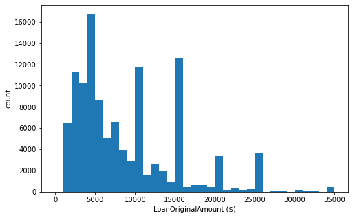

```python
bins_amount = np.arange(0, loans['LoanOriginalAmount'].max()+1000, 1000)

plt.figure(figsize=[8, 5])

plt.hist(loans['LoanOriginalAmount'], bins=bins_amount)
plt.xlabel('LoanOriginalAmount ($)')
plt.ylabel('count');
```

Now, let's investigate the the others quantitative variables.

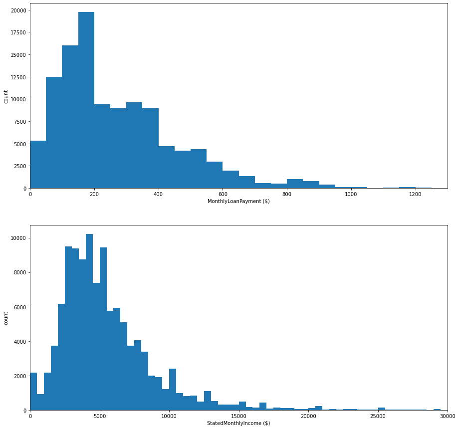

```python
# First plot the distribution in the simple form
fig, ax = plt.subplots(nrows=2, figsize = [15,15])

bins_payment = np.arange(0, loans['MonthlyLoanPayment'].max()+50, 50)

ax[0].hist(loans['MonthlyLoanPayment'], bins=bins_payment)
ax[0].set_xlabel('MonthlyLoanPayment ($)')
ax[0].set_ylabel('count')
# There isn't a lot of loans with `MonthlyLoanPayment` above 1300$. So in order to better visualize the trend of majority of
# observations the x axis limit was applied
ax[0].set_xlim(0, 1300)

bins_income = np.arange(0, loans['StatedMonthlyIncome'].max()+500, 500)

ax[1].hist(loans['StatedMonthlyIncome'], bins=bins_income)
ax[1].set_xlabel('StatedMonthlyIncome ($)')
ax[1].set_ylabel('count')
ax[1].ticklabel_format(style='plain')
# There isn't a lot of loans with `StatedMonthlyIncome` above 30000$. So in order to better visualize the trend of majority of
# observations the x axis limit was applied
ax[1].set_xlim(0, 30000);
```

- In case of `MonthlyLoanPayment`: this distribution is unimodal with the peak around \$200 and the higher the variable gets the smaller the count. This distribution is slightly skewed right.
- In case of `StatedMonthlyIncome`: the distribution is unimodal with the peak around \$4000

I'm getting closer look at `DateCreditPulled` variable

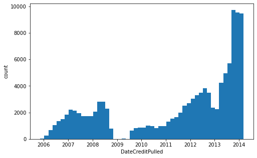

```python
plt.figure(figsize=[8, 5])

plt.hist(data=loans, x='DateCreditPulled', bins=50)
plt.xlabel('DateCreditPulled')
plt.ylabel('count');
```

The distribution of the `DateCreditPulled` are multimodal with the biggest peak in 2014, in the mid 2012 and in the mid 2008. Throught majority of 2009 the dropdown in the number of loans can be observed (this might be the result of economic crisis in 2008).

Lastly, the remaining variables were checked one by one.

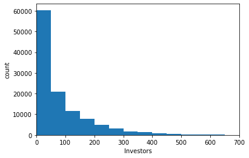

```python
bins_investors = np.arange(0, loans['Investors'].max()+50, 50)

plt.hist(loans['Investors'], bins=bins_investors)
plt.xlabel('Investors')
plt.ylabel('count')
# There isn't a lot of loans with `Investors` above 700. So in order to better visualize the trend of majority of
# observations the x axis limit was applied
plt.xlim(0, 700);
```

The distribution of `Investors` variale is right skewed and unimodal.

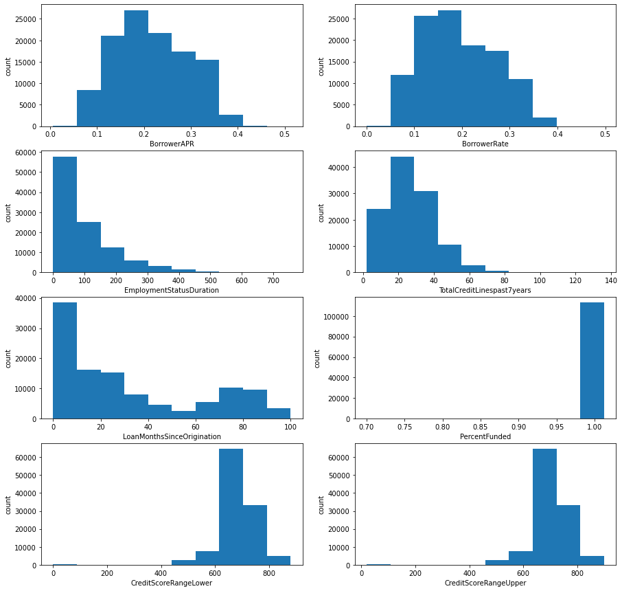

```python
fig, ax = plt.subplots(nrows=4, ncols=2, figsize = [15,15])

# bins_BorrowerARP = np.arange(0, loans['MonthlyLoanPayment'].max()+50, 50)

ax[0, 0].hist(loans['BorrowerAPR'])
ax[0, 0].set_xlabel('BorrowerAPR')
ax[0, 0].set_ylabel('count')

# bins_amount = np.arange(0, loans['LoanOriginalAmount'].max()+500, 500)

ax[0, 1].hist(loans['BorrowerRate'])
ax[0, 1].set_xlabel('BorrowerRate')
ax[0, 1].set_ylabel('count')

ax[1, 0].hist(loans['EmploymentStatusDuration'])
ax[1, 0].set_xlabel('EmploymentStatusDuration')
ax[1, 0].set_ylabel('count')

ax[1, 1].hist(loans['TotalCreditLinespast7years'])
ax[1, 1].set_xlabel('TotalCreditLinespast7years')
ax[1, 1].set_ylabel('count')

ax[2, 0].hist(loans['LoanMonthsSinceOrigination'])
ax[2, 0].set_xlabel('LoanMonthsSinceOrigination')
ax[2, 0].set_ylabel('count')

ax[2, 1].hist(loans['PercentFunded'])
ax[2, 1].set_xlabel('PercentFunded')
ax[2, 1].set_ylabel('count')

ax[3, 0].hist(loans['CreditScoreRangeLower'])
ax[3, 0].set_xlabel('CreditScoreRangeLower')
ax[3, 0].set_ylabel('count')

ax[3, 1].hist(loans['CreditScoreRangeUpper'])
ax[3, 1].set_xlabel('CreditScoreRangeUpper')
ax[3, 1].set_ylabel('count');
```

```python
column_list = ['ListingKey', 'DateCreditPulled', 'Term', 'LoanStatus', 'Investors', 'BorrowerAPR', 'BorrowerRate',
               'ListingCategory (numeric)', 'ListingCategory (name)', 'BorrowerState', 'Occupation', 'EmploymentStatus', 'EmploymentStatusDuration',
               'IsBorrowerHomeowner', 'TotalCreditLinespast7years', 'MonthlyLoanPayment',
               'LoanOriginalAmount', 'LoanMonthsSinceOrigination', 'StatedMonthlyIncome', 'IncomeRange',
               'CreditScoreRangeLower', 'CreditScoreRangeUpper']
loans = loans[column_list]
loans.head()
```

|  | ListingKey | DateCreditPulled | Term | LoanStatus | Investors | BorrowerAPR | BorrowerRate | ListingCategory (numeric) | ListingCategory (name) | BorrowerState | Occupation | EmploymentStatus | EmploymentStatusDuration | IsBorrowerHomeowner | TotalCreditLinespast7years | MonthlyLoanPayment | LoanOriginalAmount | LoanMonthsSinceOrigination | StatedMonthlyIncome | IncomeRange | CreditScoreRangeLower | CreditScoreRangeUpper |
| --- | --- | --- | --- | --- | --- | --- | --- | --- | --- | --- | --- | --- | --- | --- | --- | --- | --- | --- | --- | --- | --- | --- |
| 0 | 1021339766868145413AB3B | 2007-08-26 18:41:46.780 | 36 | Completed | 258 | 0.16516 | 0.1580 | 0 | Not Available | CO | Other | Self-employed | 2.0 | True | 12.0 | 330.43 | 9425 | 78 | 3083.333333 | $25,000-49,999 | 640.0 | 659.0 |
| 1 | 10273602499503308B223C1 | 2014-02-27 08:28:14.000 | 36 | Current | 1 | 0.12016 | 0.0920 | 2 | Home Improvement | CO | Professional | Employed | 44.0 | False | 29.0 | 318.93 | 10000 | 0 | 6125.000000 | $50,000-74,999 | 680.0 | 699.0 |
| 2 | 0EE9337825851032864889A | 2007-01-02 14:09:10.060 | 36 | Completed | 41 | 0.28269 | 0.2750 | 0 | Not Available | GA | Other | Not available | NaN | False | 3.0 | 123.32 | 3001 | 86 | 2083.333333 | Not displayed | 480.0 | 499.0 |
| 3 | 0EF5356002482715299901A | 2012-10-22 11:02:32.000 | 36 | Current | 158 | 0.12528 | 0.0974 | 16 | Motorcycle | GA | Skilled Labor | Employed | 113.0 | True | 29.0 | 321.45 | 10000 | 16 | 2875.000000 | $25,000-49,999 | 800.0 | 819.0 |
| 4 | 0F023589499656230C5E3E2 | 2013-09-14 18:38:44.000 | 36 | Current | 20 | 0.24614 | 0.2085 | 2 | Home Improvement | MN | Executive | Employed | 44.0 | True | 49.0 | 563.97 | 15000 | 6 | 9583.333333 | $100,000+ | 680.0 | 699.0 |

For the `CreditScoreRangeLower` and `CreditScoreRangeUpper`, those really low values seems a little bit suspicious to me, so I will take a closer look at it.

```python
loans.sort_values('CreditScoreRangeLower')
```

|  | ListingKey | DateCreditPulled | Term | LoanStatus | Investors | BorrowerAPR | BorrowerRate | ListingCategory (numeric) | ListingCategory (name) | BorrowerState | Occupation | EmploymentStatus | EmploymentStatusDuration | IsBorrowerHomeowner | TotalCreditLinespast7years | MonthlyLoanPayment | LoanOriginalAmount | LoanMonthsSinceOrigination | StatedMonthlyIncome | IncomeRange | CreditScoreRangeLower | CreditScoreRangeUpper |
| --- | --- | --- | --- | --- | --- | --- | --- | --- | --- | --- | --- | --- | --- | --- | --- | --- | --- | --- | --- | --- | --- | --- |
| 31084 | 156B3365591593953EB1AA1 | 2006-07-07 14:52:11.023 | 36 | Defaulted | 14 | 0.29720 | 0.2875 | 0 | Not Available | TX | Food Service | Not available | NaN | False | 4.0 | 83.54 | 2000 | 92 | 1333.333333 | Not displayed | 0.0 | 19.0 |
| 794 | 00EF338150577356881AD6B | 2007-02-11 12:46:31.633 | 36 | Completed | 38 | 0.29776 | 0.2900 | 0 | Not Available | NaN | Other | Not available | NaN | False | NaN | 167.62 | 4000 | 85 | 115.583333 | Not displayed | 0.0 | 19.0 |
| 56732 | 1FE03381020349459F57940 | 2007-02-04 21:08:47.923 | 36 | Defaulted | 36 | 0.29776 | 0.2900 | 0 | Not Available | CA | Engineer - Mechanical | Not available | NaN | False | 7.0 | 125.72 | 3000 | 85 | 2500.000000 | Not displayed | 0.0 | 19.0 |
| 54114 | 5D603366087340332B71F19 | 2006-07-13 13:20:29.117 | 36 | Defaulted | 13 | 0.21230 | 0.2000 | 0 | Not Available | KS | Tradesman - Mechanic | Not available | NaN | False | 6.0 | 55.75 | 1500 | 92 | 5416.666667 | Not displayed | 0.0 | 19.0 |
| 109468 | F6C83381122389701559A3C | 2007-02-10 13:11:33.093 | 36 | Completed | 2 | 0.12700 | 0.1200 | 0 | Not Available | CA | Homemaker | Not available | NaN | False | NaN | 84.70 | 2550 | 85 | 0.083333 | Not displayed | 0.0 | 19.0 |
| ... | ... | ... | ... | ... | ... | ... | ... | ... | ... | ... | ... | ... | ... | ... | ... | ... | ... | ... | ... | ... | ... | ... |
| 112680 | DC813364854588550A92223 | 2006-02-15 09:58:53.623 | 36 | Chargedoff | 15 | 0.14458 | 0.1375 | 0 | Not Available | NaN | NaN | NaN | NaN | False | NaN | 238.39 | 7000 | 97 | 3000.000000 | Not displayed | NaN | NaN |
| 113015 | EA353364765739825E3CE7F | 2006-04-03 20:54:49.090 | 36 | Completed | 88 | 0.12700 | 0.1200 | 0 | Not Available | NaN | NaN | NaN | NaN | False | NaN | 166.07 | 5000 | 95 | 3250.000000 | Not displayed | NaN | NaN |
| 113438 | F60733644194583537B6146 | 2006-02-15 15:17:54.273 | 36 | Completed | 9 | 0.08684 | 0.0800 | 0 | Not Available | NaN | NaN | NaN | NaN | False | NaN | 46.80 | 3000 | 96 | 5833.333333 | Not displayed | NaN | NaN |
| 113902 | E6D13366465509973F5E90A | 2006-03-26 00:11:04.620 | 36 | Completed | 143 | 0.08805 | 0.0812 | 0 | Not Available | NaN | NaN | NaN | NaN | False | NaN | 235.44 | 7500 | 95 | 20833.333333 | Not displayed | NaN | NaN |
| 113921 | D21A33647075665665BE266 | 2005-11-09 20:44:28.847 | 36 | Completed | 1 | NaN | 0.0400 | 0 | Not Available | NaN | NaN | NaN | NaN | False | NaN | 29.52 | 1000 | 100 | 12500.000000 | Not displayed | NaN | NaN |

113937 rows × 22 columns

```python
loans.sort_values('CreditScoreRangeUpper')
```

|  | ListingKey | DateCreditPulled | Term | LoanStatus | Investors | BorrowerAPR | BorrowerRate | ListingCategory (numeric) | ListingCategory (name) | BorrowerState | Occupation | EmploymentStatus | EmploymentStatusDuration | IsBorrowerHomeowner | TotalCreditLinespast7years | MonthlyLoanPayment | LoanOriginalAmount | LoanMonthsSinceOrigination | StatedMonthlyIncome | IncomeRange | CreditScoreRangeLower | CreditScoreRangeUpper |
| --- | --- | --- | --- | --- | --- | --- | --- | --- | --- | --- | --- | --- | --- | --- | --- | --- | --- | --- | --- | --- | --- | --- |
| 31084 | 156B3365591593953EB1AA1 | 2006-07-07 14:52:11.023 | 36 | Defaulted | 14 | 0.29720 | 0.2875 | 0 | Not Available | TX | Food Service | Not available | NaN | False | 4.0 | 83.54 | 2000 | 92 | 1333.333333 | Not displayed | 0.0 | 19.0 |
| 794 | 00EF338150577356881AD6B | 2007-02-11 12:46:31.633 | 36 | Completed | 38 | 0.29776 | 0.2900 | 0 | Not Available | NaN | Other | Not available | NaN | False | NaN | 167.62 | 4000 | 85 | 115.583333 | Not displayed | 0.0 | 19.0 |
| 56732 | 1FE03381020349459F57940 | 2007-02-04 21:08:47.923 | 36 | Defaulted | 36 | 0.29776 | 0.2900 | 0 | Not Available | CA | Engineer - Mechanical | Not available | NaN | False | 7.0 | 125.72 | 3000 | 85 | 2500.000000 | Not displayed | 0.0 | 19.0 |
| 54114 | 5D603366087340332B71F19 | 2006-07-13 13:20:29.117 | 36 | Defaulted | 13 | 0.21230 | 0.2000 | 0 | Not Available | KS | Tradesman - Mechanic | Not available | NaN | False | 6.0 | 55.75 | 1500 | 92 | 5416.666667 | Not displayed | 0.0 | 19.0 |
| 109468 | F6C83381122389701559A3C | 2007-02-10 13:11:33.093 | 36 | Completed | 2 | 0.12700 | 0.1200 | 0 | Not Available | CA | Homemaker | Not available | NaN | False | NaN | 84.70 | 2550 | 85 | 0.083333 | Not displayed | 0.0 | 19.0 |
| ... | ... | ... | ... | ... | ... | ... | ... | ... | ... | ... | ... | ... | ... | ... | ... | ... | ... | ... | ... | ... | ... | ... |
| 112680 | DC813364854588550A92223 | 2006-02-15 09:58:53.623 | 36 | Chargedoff | 15 | 0.14458 | 0.1375 | 0 | Not Available | NaN | NaN | NaN | NaN | False | NaN | 238.39 | 7000 | 97 | 3000.000000 | Not displayed | NaN | NaN |
| 113015 | EA353364765739825E3CE7F | 2006-04-03 20:54:49.090 | 36 | Completed | 88 | 0.12700 | 0.1200 | 0 | Not Available | NaN | NaN | NaN | NaN | False | NaN | 166.07 | 5000 | 95 | 3250.000000 | Not displayed | NaN | NaN |
| 113438 | F60733644194583537B6146 | 2006-02-15 15:17:54.273 | 36 | Completed | 9 | 0.08684 | 0.0800 | 0 | Not Available | NaN | NaN | NaN | NaN | False | NaN | 46.80 | 3000 | 96 | 5833.333333 | Not displayed | NaN | NaN |
| 113902 | E6D13366465509973F5E90A | 2006-03-26 00:11:04.620 | 36 | Completed | 143 | 0.08805 | 0.0812 | 0 | Not Available | NaN | NaN | NaN | NaN | False | NaN | 235.44 | 7500 | 95 | 20833.333333 | Not displayed | NaN | NaN |
| 113921 | D21A33647075665665BE266 | 2005-11-09 20:44:28.847 | 36 | Completed | 1 | NaN | 0.0400 | 0 | Not Available | NaN | NaN | NaN | NaN | False | NaN | 29.52 | 1000 | 100 | 12500.000000 | Not displayed | NaN | NaN |

113937 rows × 22 columns

In case of loans with very low credit score, the amount of loans is also little, so this values seems to possible for me

Lastly, I'm getting closer look at the qualitative variables.

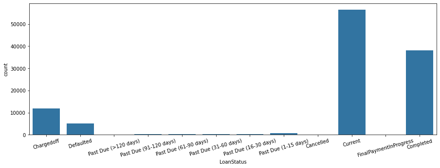

```python
# Since the `LoanStatus` is categorical variable I chose the bar plot for this visualization
plt.figure(figsize=(15,5))

sb.countplot(data=loans, x = 'LoanStatus', color = sb.color_palette()[0])

plt.xticks(rotation=15);
```

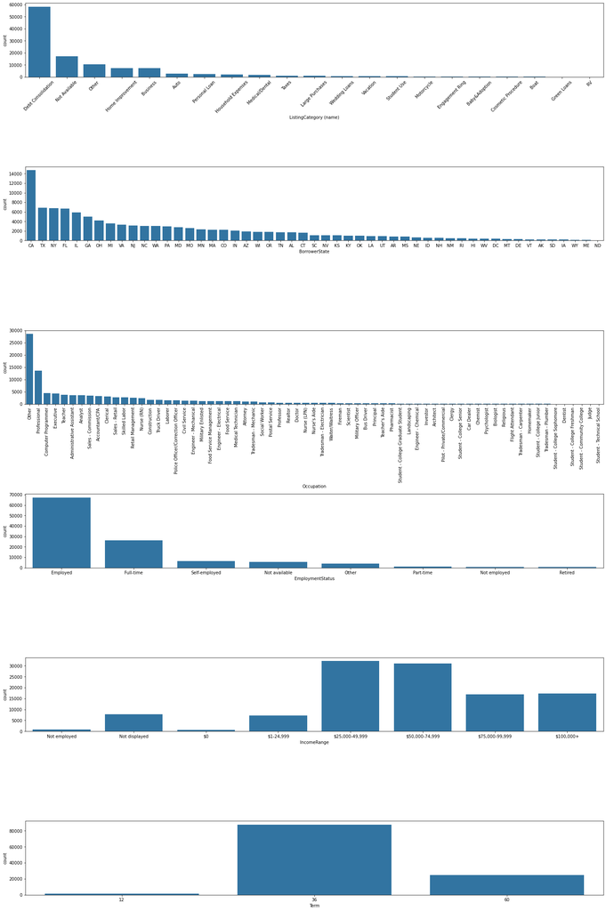

```python
# The distribution for other qualitative variables
fig, ax = plt.subplots(nrows=6, figsize = [20,30])

sb.countplot(data=loans, x='ListingCategory (name)', color=sb.color_palette()[0], ax=ax[0], order=loans['ListingCategory (name)'].value_counts().index)
ax[0].tick_params(axis='x', rotation=45)

sb.countplot(data=loans, x='BorrowerState', color=sb.color_palette()[0], ax=ax[1], order=loans['BorrowerState'].value_counts().index)

sb.countplot(data=loans, x='Occupation', color=sb.color_palette()[0], ax=ax[2], order=loans['Occupation'].value_counts().index)
ax[2].tick_params(axis='x', rotation=90)

sb.countplot(data=loans, x='EmploymentStatus', color=sb.color_palette()[0], ax=ax[3], order=loans['EmploymentStatus'].value_counts().index)

sb.countplot(data=loans, x='IncomeRange', color=sb.color_palette()[0], ax=ax[4])

sb.countplot(data=loans, x='Term', color=sb.color_palette()[0], ax=ax[5])

plt.tight_layout()
plt.show()
```

### Discuss the distribution(s) of your variable(s) of interest. Were there any unusual points? Did you need to perform any transformations?

The main variable of interest (`LoanOriginalAmount`) is quantitative. The distribution has several peaks across.

## Bivariate Exploration

First, I will investigate the relationship between my main quantitative variable (`LoanOriginalAmount`) with other quantitative variables.

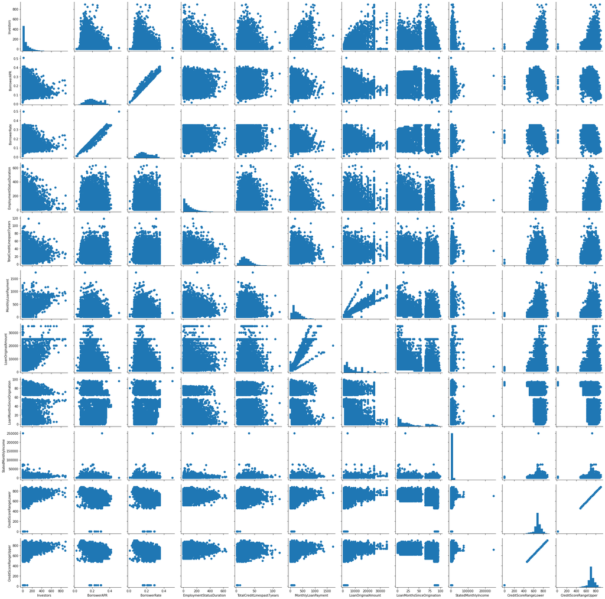

```python
# Because there are a lot of records in the dataset, the PairGrid plot are hard to read, so I decided to randomly sample
# the records, to investigate those relationship.

quan_vars = ['Investors', 'BorrowerAPR', 'BorrowerRate', 'EmploymentStatusDuration', 'TotalCreditLinespast7years',
             'MonthlyLoanPayment', 'LoanOriginalAmount', 'LoanMonthsSinceOrigination', 'StatedMonthlyIncome',
             'CreditScoreRangeLower', 'CreditScoreRangeUpper']

loans_sample = loans.sample(n=10000, replace = False)

g = sb.PairGrid(data=loans_sample, vars=quan_vars)
g = g.map_diag(plt.hist, bins = 20);
g.map_offdiag(plt.scatter);
```

As expected, `LoanOriginationAmount` is positively correlated with the `MonthlyLoanPayment`. Similar relationship can be observed in case of `BorrowerAPR` and `BorrowerRate`.  
Interestingly, from this plot there isn't such a visible relationship between `StatedMonthlyIncome` and `LoanOriginalAmount`, `LoanOriginalAmount` and `EmploymentStatusDuration`, as well as `LoanOriginalAmount` and `TotalCreditLinespast7years`.  
So, I decided to add another visualization of this variables, which is correlation matrix.

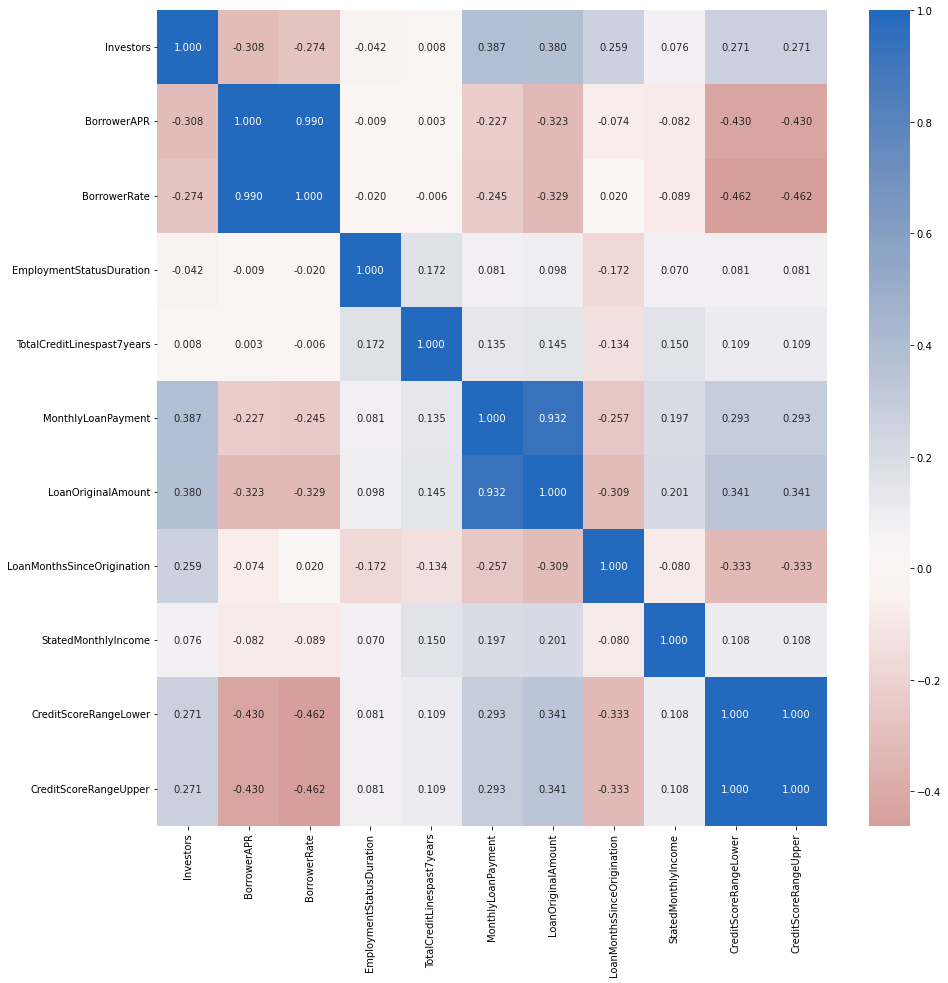

```python
# correlation matrix
plt.figure(figsize = [15, 15])
sb.heatmap(loans[quan_vars].corr(), annot = True, fmt = '.3f',
           cmap = 'vlag_r', center = 0)
plt.show()
```

From the correlation matrix I can see that there must be some relationship between `StatedMonthlyIncome` and `LoanOriginalAmount`, but this relationship is rather not a linear one. Taking into account the correlation coefficient, the `LoanOriginalAmount` and `EmploymentStatusDuration`, as well as `LoanOriginalAmount` and `TotalCreditLinespast7years` are basicly uncorrelated.  
Interestingly there is moderate negative correlation between Credit Scores and APR and Rate.

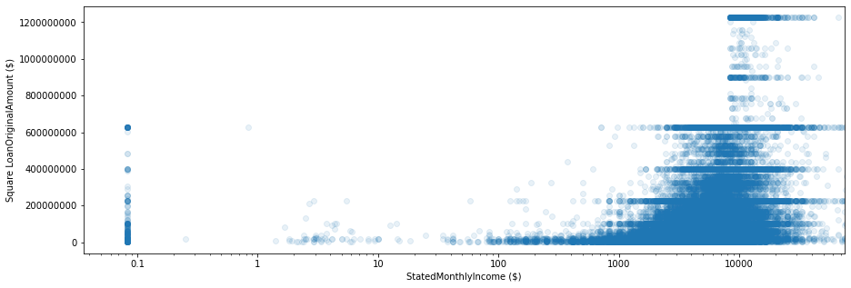

```python
loans['Income_sqr'] = loans['StatedMonthlyIncome']*loans['StatedMonthlyIncome']
loans['Loan_sqr'] = loans['LoanOriginalAmount']*loans['LoanOriginalAmount']

plt.figure(figsize = [15, 5])
plt.scatter(data=loans, x='StatedMonthlyIncome', y='Loan_sqr', alpha=1/10)
plt.ticklabel_format(style='plain')
plt.xscale('log')
plt.xlim(0, 75000)
plt.xlabel('StatedMonthlyIncome ($)')
plt.ylabel('Square LoanOriginalAmount ($)')


ticks = [0.1, 1, 10, 100, 1000, 10000]
labels = ['{}'.format(v) for v in ticks]
plt.xticks(ticks, labels);
```

The relationship between square `LoanOriginalAmount` and `StatedMonthlyIncome` appears to be not linear but it is closer to exponential.

Finally, in this part of the Bivariate Exploration I would like to check the relationship between average `LoanOriginalAmount` and the date the loan was pulled.

```python
# Check the relationship between the date and loan status
# To allow efficient ploting, the new column `YearCreditPulled` will be added based on the `DateCreditPulled`
loans['YearCreditPulled'] = pd.DatetimeIndex(df['DateCreditPulled']).year
loans.head()
```

|  | ListingKey | DateCreditPulled | Term | LoanStatus | Investors | BorrowerAPR | BorrowerRate | ListingCategory (numeric) | ListingCategory (name) | BorrowerState | Occupation | EmploymentStatus | EmploymentStatusDuration | IsBorrowerHomeowner | TotalCreditLinespast7years | MonthlyLoanPayment | LoanOriginalAmount | LoanMonthsSinceOrigination | StatedMonthlyIncome | IncomeRange | CreditScoreRangeLower | CreditScoreRangeUpper | Income_sqr | Loan_sqr | YearCreditPulled |
| --- | --- | --- | --- | --- | --- | --- | --- | --- | --- | --- | --- | --- | --- | --- | --- | --- | --- | --- | --- | --- | --- | --- | --- | --- | --- |
| 0 | 1021339766868145413AB3B | 2007-08-26 18:41:46.780 | 36 | Completed | 258 | 0.16516 | 0.1580 | 0 | Not Available | CO | Other | Self-employed | 2.0 | True | 12.0 | 330.43 | 9425 | 78 | 3083.333333 | $25,000-49,999 | 640.0 | 659.0 | 9.506944e+06 | 88830625 | 2007 |
| 1 | 10273602499503308B223C1 | 2014-02-27 08:28:14.000 | 36 | Current | 1 | 0.12016 | 0.0920 | 2 | Home Improvement | CO | Professional | Employed | 44.0 | False | 29.0 | 318.93 | 10000 | 0 | 6125.000000 | $50,000-74,999 | 680.0 | 699.0 | 3.751562e+07 | 100000000 | 2014 |
| 2 | 0EE9337825851032864889A | 2007-01-02 14:09:10.060 | 36 | Completed | 41 | 0.28269 | 0.2750 | 0 | Not Available | GA | Other | Not available | NaN | False | 3.0 | 123.32 | 3001 | 86 | 2083.333333 | Not displayed | 480.0 | 499.0 | 4.340278e+06 | 9006001 | 2007 |
| 3 | 0EF5356002482715299901A | 2012-10-22 11:02:32.000 | 36 | Current | 158 | 0.12528 | 0.0974 | 16 | Motorcycle | GA | Skilled Labor | Employed | 113.0 | True | 29.0 | 321.45 | 10000 | 16 | 2875.000000 | $25,000-49,999 | 800.0 | 819.0 | 8.265625e+06 | 100000000 | 2012 |
| 4 | 0F023589499656230C5E3E2 | 2013-09-14 18:38:44.000 | 36 | Current | 20 | 0.24614 | 0.2085 | 2 | Home Improvement | MN | Executive | Employed | 44.0 | True | 49.0 | 563.97 | 15000 | 6 | 9583.333333 | $100,000+ | 680.0 | 699.0 | 9.184028e+07 | 225000000 | 2013 |

```python
loans_agg = loans.groupby('YearCreditPulled')['LoanOriginalAmount'].mean().to_frame()
loans_agg.reset_index(level=0, inplace=True)
loans_agg.rename(columns={'LoanOriginalAmount':'LoanOriginalAmount_mean'}, inplace=True)
loans_agg
```

|  | YearCreditPulled | LoanOriginalAmount_mean |
| --- | --- | --- |
| 0 | 2005 | 3903.625000 |
| 1 | 2006 | 4878.130394 |
| 2 | 2007 | 7064.441824 |
| 3 | 2008 | 5989.777346 |
| 4 | 2009 | 4369.210263 |
| 5 | 2010 | 4823.246709 |
| 6 | 2011 | 6692.680836 |
| 7 | 2012 | 7879.574329 |
| 8 | 2013 | 10609.520454 |
| 9 | 2014 | 11902.113989 |

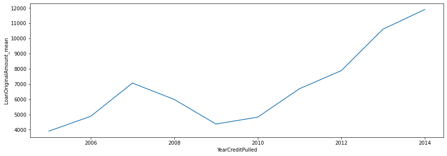

```python
plt.figure(figsize=(15,5))
sb.lineplot(data=loans_agg, x='YearCreditPulled', y='LoanOriginalAmount_mean');
```

It turned out that since 2009 the average amount of loan increases.

Finally, I want to take a look at relationship between the `LoanOriginalAmount` and the qualitative variables. For this visualizations the box plot were chosen

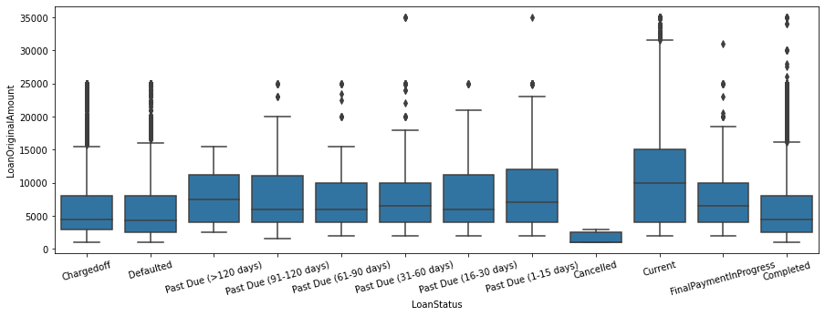

```python
plt.figure(figsize=(15,5))
sb.boxplot(data=loans, x='LoanStatus', y='LoanOriginalAmount', color=sb.color_palette()[0])
plt.xticks(rotation=15);
```

The Cancelled Loans has the smalles `LoanOriginalAmount`, while the Current has the biggest.

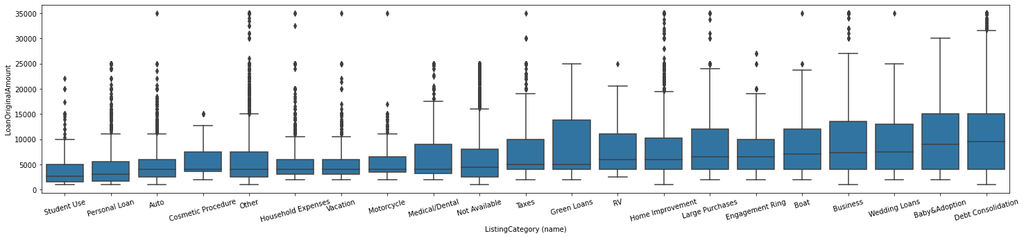

```python
# Define the order
cat_order = loans.groupby('ListingCategory (name)')['LoanOriginalAmount'].median().sort_values().index

plt.figure(figsize=(25,5))
sb.boxplot(data=loans, x='ListingCategory (name)', y='LoanOriginalAmount', color=sb.color_palette()[0], order=cat_order)
plt.xticks(rotation=15);
```

There are some loan types which have bigger loan amount. These are: Dept Consoliodation, Baby&Adoption, Wedding Loans. So The amount of loan may depend on the loan type.

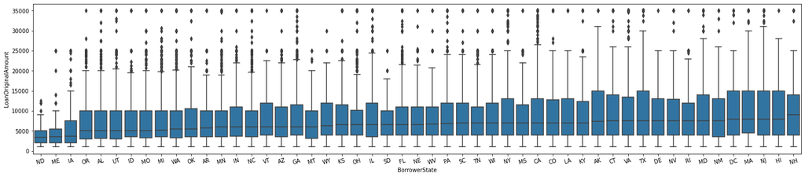

```python
# Define the order
state_order = loans.groupby('BorrowerState')['LoanOriginalAmount'].median().sort_values().index

plt.figure(figsize=(25,5))
sb.boxplot(data=loans, x='BorrowerState', y='LoanOriginalAmount', color=sb.color_palette()[0], order=state_order)
plt.xticks(rotation=15);
```

Borrowers from most states have similar loan amount. Howver three states have lower loan amount. Thee are ND, ME, IA.

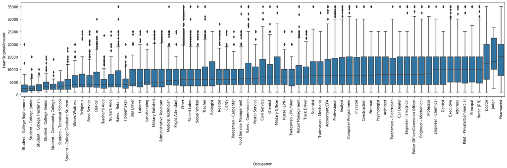

```python
# Define the order
occupation_order = loans.groupby('Occupation')['LoanOriginalAmount'].median().sort_values().index

plt.figure(figsize=(25,5))
sb.boxplot(data=loans, x='Occupation', y='LoanOriginalAmount', color=sb.color_palette()[0], order=occupation_order)
plt.xticks(rotation=90);
```

The amount of loan might also depend on the occupation. Doctors, judges and pharmasists received the bigegst amount of loan. While students the lowest.

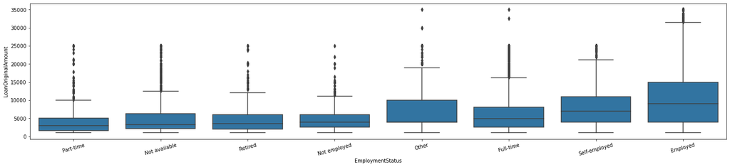

```python
# Define the order
empl_order = loans.groupby('EmploymentStatus')['LoanOriginalAmount'].median().sort_values().index

plt.figure(figsize=(25,5))
sb.boxplot(data=loans, x='EmploymentStatus', y='LoanOriginalAmount', color=sb.color_palette()[0], order=empl_order)
plt.xticks(rotation=15);
```

The amount of loan is also associated with the employment status. With Employed borrowers received the biggest amount of loans, while those with part time the lowest.

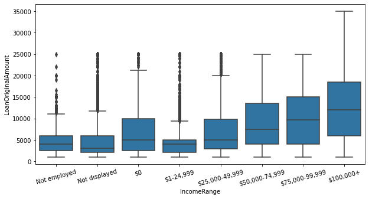

```python
plt.figure(figsize=(10,5))
sb.boxplot(data=loans, x='IncomeRange', y='LoanOriginalAmount', color=sb.color_palette()[0])
plt.xticks(rotation=15);
```

For borrowers with income higher than \$1, the bigger the Income the bigger the `LoanOriginalAmount`.

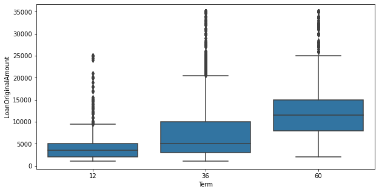

```python
plt.figure(figsize=(10,5))
sb.boxplot(data=loans, x='Term', y='LoanOriginalAmount', color=sb.color_palette()[0]);
```

The longer the term, the bigger the `LoanOriginalAmount`.

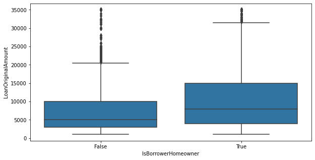

```python
plt.figure(figsize=(10,5))
sb.boxplot(data=loans, x='IsBorrowerHomeowner', y='LoanOriginalAmount', color=sb.color_palette()[0]);
```

Finally, if someone owns the house they on average receive bigger amount of loan.

### Talk about some of the relationships you observed in this part of the investigation. How did the feature(s) of interest vary with other features in the dataset?

As expected, `LoanOriginationAmount` is positively correlated with the `MonthlyLoanPayment`. From simple scatter plot it seems that there isn't such easily visible relationship between `StatedMonthlyIncome` and `LoanOriginalAmount`, `LoanOriginalAmount` and `EmploymentStatusDuration`, as well as `LoanOriginalAmount` and `TotalCreditLinespast7years`. However, from correlation matrix I can see that there must be some relationship between `StatedMonthlyIncome` and `LoanOriginalAmount`. This realtionship apeared to be more exponational.  
The `LoanOriginationAmount` is also associated with some qualitative features such as: date, loan status, listing category, state, occupation, income range, term and house ownership.  
Interestingly, the amount of loan seems to be associated with `Employment Status`, not the employment duration.

### Did you observe any interesting relationships between the other features (not the main feature(s) of interest)?

Very visible positive relationship can be observed in case of `BorrowerAPR` and `BorrowerRate`. There is also moderate negative correlation between `Credit Scores` and `APR` and `Rate`.

## Multivariate Exploration

In this part of exploration, I would like to take a closer look at the relationship between more than two variables.

First, I would like to take a closer look at the relations with date variables.

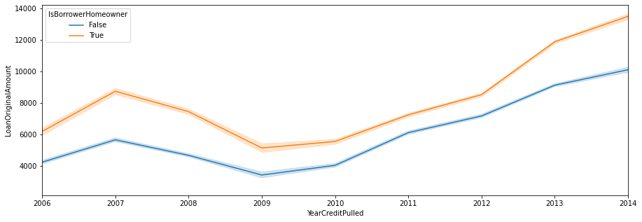

```python
plt.figure(figsize=(15,5))
sb.lineplot(data=loans, x='YearCreditPulled', y='LoanOriginalAmount', hue='IsBorrowerHomeowner')

# Because all the loan originated before 2006 have the IsBorrowerHomeowner=False, I will limit the x axis
plt.xlim(2006, 2014);
```

Throughout the analyzed period, borrowers who has the home received the bigger amount of loan.

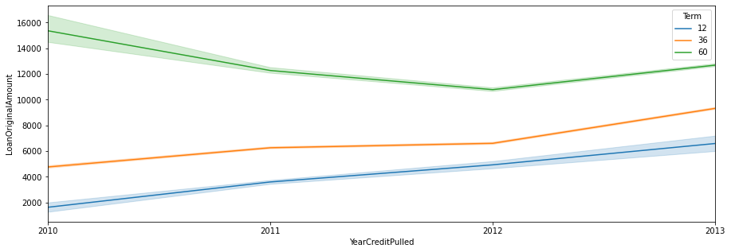

```python
plt.figure(figsize=(15,5))
sb.lineplot(data=loans, x='YearCreditPulled', y='LoanOriginalAmount', hue='Term')

# Because all the loan originated before 2010 have the term=36, I will limit the x axis
plt.xlim(2010, 2013)
plt.xticks([2010, 2011, 2012, 2013], [2010, 2011, 2012, 2013]);
```

Throughout the analyzed period, borrowers who have the loan for 60 months received the biggest amount of loan, then there were borowers with the 36 months loans. The ones with 12 months loans, received the smallest amount of loan.

```python
# For the IncomeRange I will chose only the records with the Income higher than $1
income_list = ['$1-24,999', '$25,000-49,999', '$50,000-74,999', '$75,000-99,999', '$100,000+']

loans_to_plot = loans[loans['IncomeRange'].isin(income_list)]
loans_to_plot.head()
```

|  | ListingKey | DateCreditPulled | Term | LoanStatus | Investors | BorrowerAPR | BorrowerRate | ListingCategory (numeric) | ListingCategory (name) | BorrowerState | Occupation | EmploymentStatus | EmploymentStatusDuration | IsBorrowerHomeowner | TotalCreditLinespast7years | MonthlyLoanPayment | LoanOriginalAmount | LoanMonthsSinceOrigination | StatedMonthlyIncome | IncomeRange | CreditScoreRangeLower | CreditScoreRangeUpper | Income_sqr | Loan_sqr | YearCreditPulled |
| --- | --- | --- | --- | --- | --- | --- | --- | --- | --- | --- | --- | --- | --- | --- | --- | --- | --- | --- | --- | --- | --- | --- | --- | --- | --- |
| 0 | 1021339766868145413AB3B | 2007-08-26 18:41:46.780 | 36 | Completed | 258 | 0.16516 | 0.1580 | 0 | Not Available | CO | Other | Self-employed | 2.0 | True | 12.0 | 330.43 | 9425 | 78 | 3083.333333 | $25,000-49,999 | 640.0 | 659.0 | 9.506944e+06 | 88830625 | 2007 |
| 1 | 10273602499503308B223C1 | 2014-02-27 08:28:14.000 | 36 | Current | 1 | 0.12016 | 0.0920 | 2 | Home Improvement | CO | Professional | Employed | 44.0 | False | 29.0 | 318.93 | 10000 | 0 | 6125.000000 | $50,000-74,999 | 680.0 | 699.0 | 3.751562e+07 | 100000000 | 2014 |
| 3 | 0EF5356002482715299901A | 2012-10-22 11:02:32.000 | 36 | Current | 158 | 0.12528 | 0.0974 | 16 | Motorcycle | GA | Skilled Labor | Employed | 113.0 | True | 29.0 | 321.45 | 10000 | 16 | 2875.000000 | $25,000-49,999 | 800.0 | 819.0 | 8.265625e+06 | 100000000 | 2012 |
| 4 | 0F023589499656230C5E3E2 | 2013-09-14 18:38:44.000 | 36 | Current | 20 | 0.24614 | 0.2085 | 2 | Home Improvement | MN | Executive | Employed | 44.0 | True | 49.0 | 563.97 | 15000 | 6 | 9583.333333 | $100,000+ | 680.0 | 699.0 | 9.184028e+07 | 225000000 | 2013 |
| 5 | 0F05359734824199381F61D | 2013-12-14 08:26:40.000 | 60 | Current | 1 | 0.15425 | 0.1314 | 1 | Debt Consolidation | NM | Professional | Employed | 82.0 | True | 49.0 | 342.37 | 15000 | 3 | 8333.333333 | $100,000+ | 740.0 | 759.0 | 6.944444e+07 | 225000000 | 2013 |

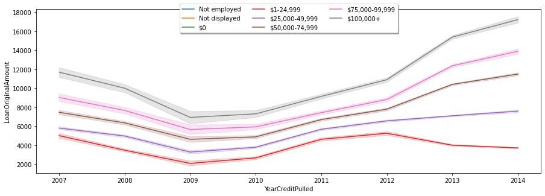

```python
plt.figure(figsize=(15,5))
sb.lineplot(data=loans_to_plot, x='YearCreditPulled', y='LoanOriginalAmount', hue='IncomeRange')

plt.legend(loc='upper center', bbox_to_anchor=(0.5, 1.05),
          ncol=3, fancybox=True, shadow=True);
```

Throughout the analyzed period, the `IncomeRange` were positivly associated with the amount of loan.

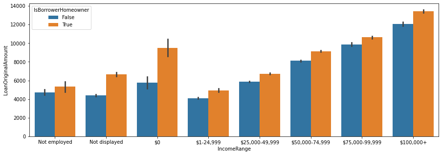

```python
plt.figure(figsize=(15,5))
sb.barplot(data=loans, x='IncomeRange', y='LoanOriginalAmount', hue='IsBorrowerHomeowner');
```

When taking into account the my variable of interest (`LoanOriginalAmount`) and other two categorical variables (`IsBorrowerHomeowner` and `IncomeRange`), I can see that the fact of house ownership increases the amount of credit granted for the same income ranges.

### Talk about some of the relationships you observed in this part of the investigation. Were there features that strengthened each other in terms of looking at your feature(s) of interest?

In this part of the analysis I extended the investigation about the features which impact the amount of loan and look at the combination of more than two variables. First, I investigate the relationship between `LoanOriginalAmount`, date and other categorical variables. The Multivariate Exploration shows that `LoanOriginalAmount` is associated with many features and also combination of those features may be usefull in predicting the amount of loan. For example, the fact of possesing the house strengthened the amount of received loan in each income range.

## Conclusions

- date,
- stated monthly income,
- income ranges,
- occupation,
- employment status,
- term,
- house ownership.